# Time Series Analysis of value of real estate in the U.S

## 2.2 Model Selection

Next, we can fit stationary Gaussian ARIMA$(p,0,q)$. It is natural to choose $(p,q)$ by AIC scores. The lower AIC score reflects the higher log-likelihood and fewer parameters.

|  | MA0 | MA1 | MA2 | MA3 | MA4 | MA5 |
| --- | --- | --- | --- | --- | --- | --- |
| AR0 | 24944.55 | 24913.24 | 24853.57 | 24855.42 | 24854.32 | 24829.97 |
| AR1 | 24903.02 | 24890.29 | 24855.47 | 24828.00 | 24822.29 | 24816.36 |
| AR2 | 24866.80 | 24859.56 | 24853.65 | 24815.17 | 24805.38 | 24813.34 |
| AR3 | 24852.33 | 24810.55 | 24811.35 | 24808.65 | 24808.96 | 24803.54 |
| AR4 | 24842.30 | 24811.64 | 24814.54 | 24808.68 | 24810.70 | 24812.90 |
| AR5 | 24824.77 | 24812.44 | 24808.05 | 24811.62 | 24811.51 | 24808.64 |

Also it is noticable that the table is inconsistent — adding a parameter can only increase the maximized log-likelihood, i.e. the AIC can only increase by $$2. But there are several positions violating such a rule. This can only come about by imperfect likelihood calculation and/or maximization. We may suspect a problem with likelihood maximization.

## 2.3 Fit a Model

We first fit the ARIMA(4,0,0) model:

```
##
## Call:
## arima(x = detrend, order = c(4, 0, 0))
##
## Coefficients:
##           ar1     ar2     ar3      ar4  intercept
##       -0.1274  0.1522  0.0961  -0.0853     1.1725
## s.e.   0.0222  0.0222  0.0241   0.0245     2.2632
##
## sigma^2 estimated as 9830:  log likelihood = -12416.15,  aic = 24842.3
```

Then we fit the ARIMA(4,0,1) model:

```
##
## Call:
## arima(x = detrend, order = c(4, 0, 1))
##
## Coefficients:
##           ar1     ar2     ar3      ar4     ma1  intercept
##       -0.8948  0.0489  0.2087  -0.0276  0.7864     1.1776
## s.e.   0.0525  0.0303  0.0312   0.0284  0.0472     2.3232
##
## sigma^2 estimated as 9675:  log likelihood = -12399.82,  aic = 24811.64
```

We then want to decide which model is better.

```
## Likelihood ratio test
##
## Model 1: arima(x = detrend, order = c(4, 0, 0))
## Model 2: arima(x = detrend, order = c(4, 0, 1))
##   #Df LogLik Df  Chisq Pr(>Chisq)
## 1   6 -12416
## 2   7 -12400  1 32.668  1.093e-08 ***
## ---
## Signif. codes:  0 '***' 0.001 '**' 0.01 '*' 0.05 '.' 0.1 ' ' 1
```

```
## Likelihood ratio test
##
## Model 1: arima(x = detrend, order = c(0, 0, 0))
## Model 2: arima(x = detrend, order = c(4, 0, 0))
##   #Df LogLik Df  Chisq Pr(>Chisq)
## 1   2 -12471
## 2   6 -12416  4 110.25  < 2.2e-16 ***
## ---
## Signif. codes:  0 '***' 0.001 '**' 0.01 '*' 0.05 '.' 0.1 ' ' 1
```

# 3 Diagnostics

As we have choosed ARIMA(4,0,0) model as before, we will do some diagnostics for the fitted model.

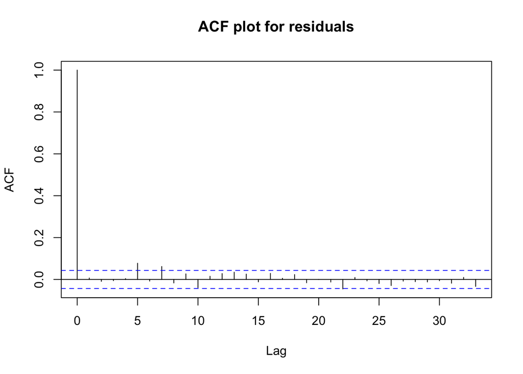

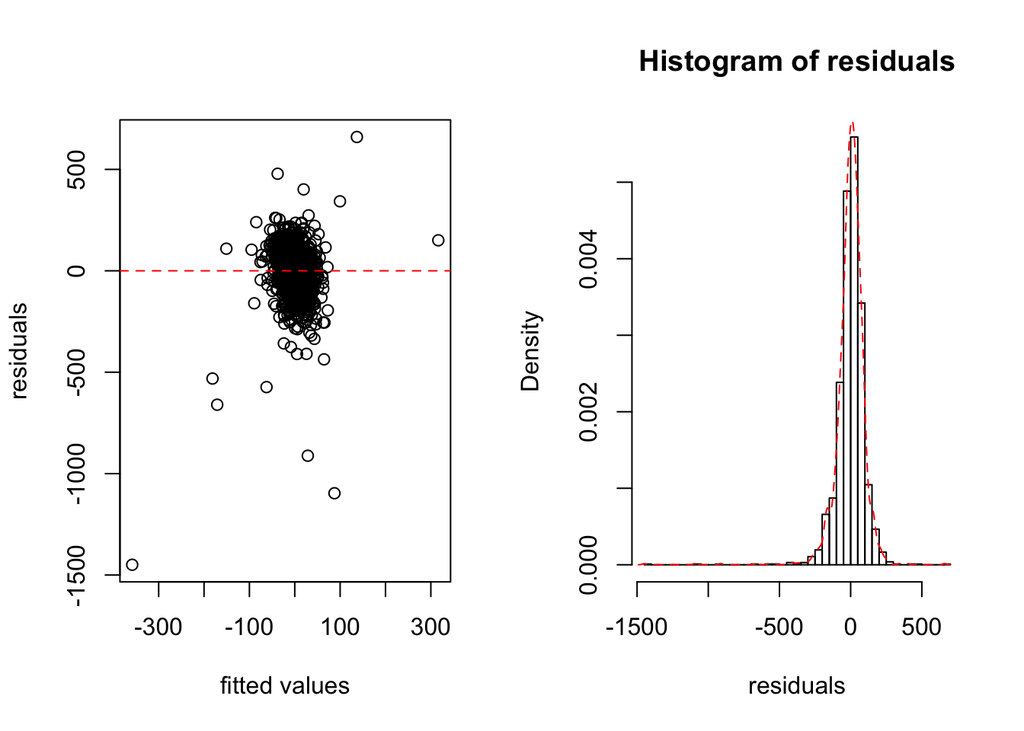

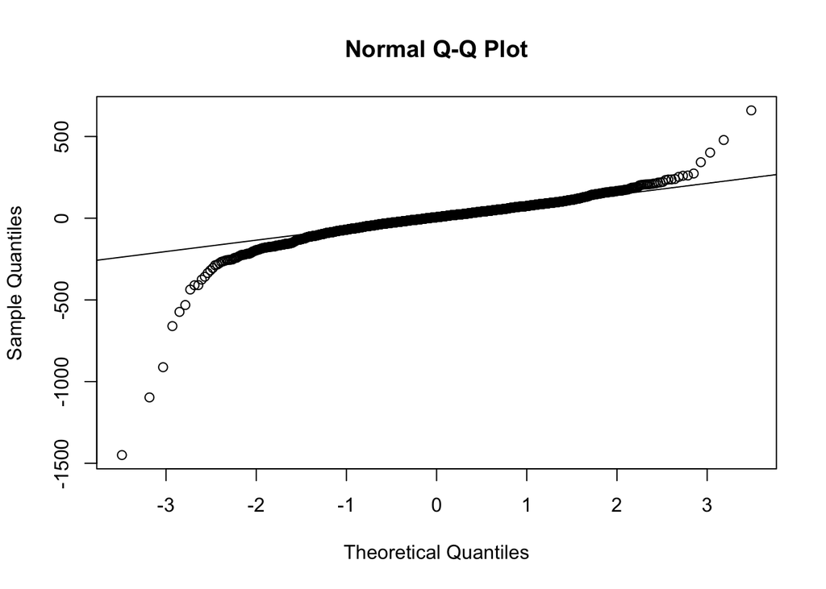

From qqplot, we can see that the distribution of residuals is long-tailed at both ends, meaning more extreme values will occur.

```
##
##  Shapiro-Wilk normality test
##
## data:  residuals(fit0)
## W = 0.83175, p-value < 2.2e-16
```

Then I conduct a Shapiro-Wilk test for the residuals. The null hypothesis for Shapiro-Wilk test is that the sequence follows normal distribution and p-value for the test is very small. Thus we have to reject the null hypothesis. As the normal assumption of residuals has been violated, the estimations of standard errors and confidence intervals are not dependable while the point estimation can still be valid. The further focuses may be transforming the sequence and looking for predictors to be added to the model.

# 4 Conclusion

Finally, the study shows that REIT index series is not an independent data. Today’s index is related to historical index. However, ARIMA(4,0,0) model may not be the most exact model, and further analysis with more complex model is needed.

# 5 Reference

- Wilshire US Real Estate Investment Trust Total Market Index([Wilshire US REIT](https://fred.stlouisfed.org/series/WILLREITIND)). FRED.
- Sildes from ionides.github.io/531w20. Prof. Edward L. Ionides.
- Derivatives and Alternative Investments, Level I Volume 6, 2019. CFA Program Curriculum.
- Time Series Analysis and its Applications, 4th edition. R. Shumway and D. Stoffer.
- Linear Model with R, 2005. Julian J. Faraway.